# aula5 slides

[figure not shown]

## Algumas referências bibliográficas

- Frery, A. e Cribari-Neto, F. (2011) [Elementos de Estatística Computacional Usando Plataformas de Software Livre/Gratuito](https://impa.br/wp-content/uploads/2017/04/PM_21.pdf). 2a impressão. IMPA.
- Dutang, C. and Wuertz, D.(2009) [A note on random number generation](http://cran-r.c3sl.ufpr.br/web/packages/randtoolbox/vignettes/fullpres.pdf).
- L'Ecuyer, P. (1999) [Good Parameters and Implementations for Combined Multiple Recursive Random Number Generators](https://pubsonline.informs.org/doi/pdf/10.1287/opre.47.1.159), Operations Research, 47(1):159-164.

# Geração de números pseudo-aleatórios

### Geradores de números pseudo-aleatórios

- A geração de eventos de variáveis aleatórias independentes e identicamente distribuidas com distribuição uniforme em $(0,1)$ é essencial para construir eventos de variáveis aleatórias com outras distribuições e/ou outras estruturas de dependência;

### Distribuição uniforme

$\begin{aligned} f(u)&=\begin{cases}1, & \text{ para } u\in(0,1);\\ 0, & \text{ em caso contrário}\end{cases}\\ F(u)&=\mathbb{P}\left[U\le u\right]=u\\ \mathbb{E}[U]&=\frac12 \qquad \mathrm{var}[U]=\frac{1}{12} \end{aligned}$

[figure not shown]

### Algoritmos

As duas propriedades básicas de um algoritmo $f:\mathbb{R}^k\longrightarrow\mathbb{R}$ capaz de gerar sequências **pseudo-aleatórias** são

1. A função $u_i = f(u_{i−1},\ldots, u_{i−k})$ deve ser de custo computacional relativamente baixo;
2. Deve ser difı́cil conhecer $u_{i−1}$ dado só o conhecimento dos valores $(u_i, u_{i−2},\ldots, u_{i−k})$.

Outras propriedades desejáveis para um gerador deste tipo de sequências são a repetibilidade, a portabilidade, a periodicidade.

# Geradores congruenciais lineares

### Geradores congruenciais

Uma classe interessante de geradores, conhecida como **congruenciais lineares**, é definida pela recursão

$$u_i \equiv (a\,u_{i−1} + c)\mod M,$$

onde $i=1,2,\ldots$, $u_0$ é chamada de *semente*, $M$ é chamado de módulo, $a$ é o multiplicador e $c$ o incremento. O operador $\equiv$ indica a [aritmética modular](https://en.wikipedia.org/wiki/Modular_arithmetic) entre os números.

```r
# Gerador congruencial linear

lcg <- function(n,a=1664525,c=1013904223,m=2 ** 32){

    rng <- numeric(n)

    seed <- as.numeric(Sys.time()) * 1000 # Semente em função do relógio do computador

    for (i in 1:n){
        seed <- (a * seed + c) %% m
        rng[i] <- seed / m
    }
    return(rng)
}

dados.lcg<-lcg(500)
```

### Geradores com recursão múltipla

Esse tipo de geradores são baseados na seguinte forma funcional:

$$x_n \equiv (a_1 x_{n−1} + \cdots + a_k x_{n−k})\mod M,$$

onde $k$ é um inteiro fixo. Para calcular os valores no intervalo $(0,1)$ calcule $u_n=\frac{x_n}{M}$.

### Geradores congruenciais combinados

Esse tipo de geradores são baseados na seguinte forma funcional:

$$x_i \equiv \Bigg(\sum^k_{j=1} (-1)^{j-1} y_{i,j} \Bigg) \mod (M – 1)),$$

onde $M$ é o módulo, $y_{i,j}$ é o $i$-ésimo elemento do $j$-ésimo gerador congruencial linear. Para calcular os valores no intervalo $(0,1)$ calcule $u_n=\frac{x_n}{M}$.

```r
# Um exemplo de um gerador congruencial combinando dois geradores congruenciais lineares.
comb.2lcg <- function(n=100, a1 = 40014, m1 = 2147483563, a2 = 40692, m2 = 2147483399){
    rng <- vector(length = n)

    y1 <- runif(1, 1, m1 - 1) # Sementes
    y2 <- runif(1, 1, m2 - 1)
    for (i in 1:n){
        y1 <- a1 * y1 %% m1
        y2 <- a2 * y2 %% m2
        x <- (y1 - y2) %% (m1 - 1)
        if (x > 0){
            rng[i] <- x / m1
        } else if (x < 0){
            rng[i] <- (x / m1) + 1
        } else if (x == 0){
            rng[i] <- (m1 - 1) / m1
        }
    }
    return(rng)
}

comb.2lcg()
```

1. 0.170386641512984

2. 0.910662409809473

3. 0.597091535071216

4. 0.175664125749702

5. 0.657859066550397

6. 0.975101466993161

7. 0.92090152996901

8. 0.62599533503391

9. 0.199902823191015

10. 0.432777548574885

11. 0.265834047736551

12. 0.556012286460513

13. 0.844918638383078

14. 0.314681702641744

15. 0.742335642268196

16. 0.623459443912866

17. 0.224815386864034

18. 0.4041368441431

19. 0.598023926295356

20. 0.890440949093309

21. 0.818960866710019

22. 0.022855902995333

23. 0.826452301930844

24. 0.0110592147987491

25. 0.000858477350776351

26. 0.569329429600854

27. 0.29889501883

28. 0.376638690947689

29. 0.0411342976132479

30. 0.137155378078207

31. 0.0680681866527516

32. 0.106682752756418

33. 0.713201855599022

34. 0.98098816880211

35. 0.912277506451862

36. 0.595239823961344

37. 0.823580600323319

38. 0.486232766569492

39. 0.736184710904816

40. 0.148125211051965

41. 0.242225156439998

42. 0.720860185694469

43. 0.78566505703215

44. 0.860949056772827

45. 0.553421278037507

46. 0.155425812681762

47. 0.286839701412886

48. 0.827920476148483

49. 0.0627603350834122

50. 0.314202294082937

51. 0.600592200202093

52. 0.909081098284523

53. 0.351760075380842

54. 0.487305926820731

55. 0.193789547529124

56. 0.589249048422169

57. 0.519029165672827

58. 0.890242278422505

59. 0.0782613803875713

60. 0.686985731308249

61. 0.421139675097946

62. 0.717376979522893

63. 0.333646538834998

64. 0.875830305016402

65. 0.423385572614043

66. 0.335579830465971

67. 0.0209510511629467

68. 0.31234309009703

69. 0.752956721000989

70. 0.355853811021696

71. 0.871070311423846

72. 0.58974179258945

73. 0.16507939064491

74. 0.78786277536691

75. 0.666976671988618

76. 0.375589734839801

77. 0.555724672617669

78. 0.733498743897021

79. 0.768581184246298

80. 0.127068000287181

81. 0.483142288898628

82. 0.601319201808484

83. 0.0819013197727558

84. 0.167811055790605

85. 0.771233000585253

86. 0.277673525550519

87. 0.91146177960292

88. 0.176062073076738

89. 0.809753194837375

90. 0.683142242984423

91. 0.525246040265036

92. 0.145849177798806

93. 0.00873787176921922

94. 0.617555781496801

95. 0.0213543911534935

96. 0.688659874040675

97. 0.612989488106271

98. 0.721433608476937

99. 0.959072679058266

100. 0.865043848533522

```r
# Um exemplo de um gerador congruencial combinando três geradores congruenciais lineares.
comb.3lcg <- function(n=100, a1 = 157, m1 = 32363, a2 = 146, m2 = 31727, a3 = 142, m3 = 31657){
    rng <- vector(length = n)
    # Sementes
    y1 <- runif(1, 1, m1 - 1)
    y2 <- runif(1, 1, m2 - 1)
    y3 <- runif(1, 1, m3 - 1)
    for (i in 1:n){
        y1 <- a1 * y1 %% m1
        y2 <- a2 * y2 %% m2
        y3 <- a3 * y3 %% m3
        x <- (y1 - y2 - y3) %% (m1 - 1)
        if (x > 0){
            rng[i] <- x / m1
        } else if (x < 0){
            rng[i] <- (x / m1) + 1
        } else if (x == 0){
            rng[i] <- (m1 - 1) / m1
        }
    }
    return(rng)
}
comb.3lcg()
```

1. 0.405819646718137

2. 0.68713195941756

3. 0.734732817465387

4. 0.954713670569308

5. 0.558300508684041

6. 0.861332994690344

7. 0.506172065427361

8. 0.0246735370562228

9. 0.0127189066876601

10. 0.370549150393291

11. 0.111926057644461

12. 0.163873240031701

13. 0.755994493325917

14. 0.293020607333203

15. 0.387524367033671

16. 0.761240764070178

17. 0.589214965249787

18. 0.239517143026782

19. 0.901795173064536

20. 0.489367159581075

21. 0.272216449305778

22. 0.411797539761471

23. 0.315294218325764

24. 0.438426131198956

25. 0.582909357498223

26. 0.560825514916776

27. 0.231955284198172

28. 0.877140528175837

29. 0.924933701964411

30. 0.705638082929674

31. 0.85726751608098

32. 0.667383549108956

33. 0.0871305679529479

34. 0.37813650136937

35. 0.585117579620414

36. 0.860339152523095

37. 0.532289680112203

38. 0.382537899545292

39. 0.502784808223362

40. 0.476967077206306

41. 0.958824169006083

42. 0.465499901195428

43. 0.767938957292534

44. 0.295304222499514

45. 0.494394734172539

46. 0.685665568027171

47. 0.824107164229012

48. 0.0327251640185612

49. 0.471070786139528

50. 0.520453132832685

51. 0.494938165333106

52. 0.663268659086724

53. 0.676948595671449

54. 0.587081607677652

55. 0.894582235135151

56. 0.883332369730494

57. 0.0902827491058751

58. 0.612422694503273

59. 0.0945585689485007

60. 0.664933343639701

61. 0.216893818039995

62. 0.619767556062601

63. 0.376243687113954

64. 0.230627198739789

65. 0.40548531199454

66. 0.362828565845218

67. 0.206336792091576

68. 0.80824965504339

69. 0.91132537244902

70. 0.213886706582093

71. 0.647666506913947

72. 0.567644922633899

73. 0.480880731036656

74. 0.0784743834215042

75. 0.617020544918956

76. 0.417076153271094

77. 0.541117358868069

78. 0.937410943127275

79. 0.533806054172836

80. 0.12318873397678

81. 0.36507272618157

82. 0.186454780892497

83. 0.941447443739739

84. 0.427586707493734

85. 0.107258674884726

86. 0.362678421692078

87. 0.294836588439105

88. 0.0487301031979268

89. 0.792393034568399

90. 0.596078148030865

91. 0.725541681596097

92. 0.616004521046632

93. 0.987159021019323

94. 0.971513807990255

95. 0.560575804907268

96. 0.685400597953992

97. 0.309126768187553

98. 0.341974693941927

99. 0.277518837767958

100. 0.32598081233054

```r
# Gerador de Wichmann-Hill de 1982

wh.predict <- function(x){
    M1 <- 30269
    M2 <- 30307
    M3 <- 30323
    y <- round(M1*M2*M3*x)
    s1 <- y %% M1
    s2 <- y %% M2
    s3 <- y %% M3
    s1 <- (171*26478*s1) %% M1
    s2 <- (172*26070*s2) %% M2
    s3 <- (170*8037*s3) %% M3
    (s1/M1 + s2/M2 + s3/M3) %% 1
}

replicate(10,wh.predict(as.numeric(Sys.time())*10e-9))
```

1. 0.933996436456117

2. 0.143517775565353

3. 0.928970714642572

4. 0.119272674027385

5. 0.714423653719791

6. 0.309574633412197

7. 0.499876592797009

8. 0.0950275724894156

9. 0.690178552181822

10. 0.285329531874228

### Geradores no `R` version 4.1.1 (2021-08-10)

Para verificar os geradores implementados no `R` use `?RNGkind`.

```r
RNGkind()
```

1. 'Mersenne-Twister'

2. 'Inversion'

3. 'Rejection'

```r
RNGkind("Marsaglia"); RNGkind()
```

1. 'Marsaglia-Multicarry'

2. 'Inversion'

3. 'Rejection'

### Verificando qualidade dos geradores

"Qualidade dos geradores" faz referência se o conjunto de valores gerados satisfazem as propriedades básicas:

1. A sequência de valores são realizações de uma amostra aleatória de variáveis uniformes no intervalo $(0,1)$;
2. Não é possível conhecer $𝑢_{𝑖−1}$ dado só o conhecimento dos outros valores da sequência.

### Verificando qualidade dos geradores

Um usuário cuidadoso de plataformas computacionais que utiliza simulação estocástica deveria verificar a qualidade dos geradores disponı́veis por meio de testes estatísticos, por exemplo:

1. Avaliação qualitativa: gráficos para avaliar a aderência à distribuição uniforme, dependência seqüencial e ausência de vazios no espaço;
2. Testes de aderência gerais: $\chi^2$ , Kolmogorov-Smirnov etc;
3. Testes de aderência especı́ficos: serial, do intervalo, pôquer, do máximo etc;
4. Testes de independência: de permutações, de dependência linear.

### Verificando qualidade dos geradores

Bassham, L. , Rukhin, A. , Soto, J. , Nechvatal, J. , Smid, M. , Leigh, S. , Levenson, M. , Vangel, M. , Heckert, N. and Banks, D. (2010), A Statistical Test Suite for Random and Pseudorandom Number Generators for Cryptographic Applications, Special Publication (NIST SP), National Institute of Standards and Technology, Gaithersburg, MD, [online], https://tsapps.nist.gov/publication/get_pdf.cfm?pub_id=906762 (Accessed August 18, 2021)

Brown, R., Eddelbuettel, D. and Bauer, D. [Dieharder: A Random Number Test Suite](https://webhome.phy.duke.edu/~rgb/General/dieharder.php), Version 3.31.1, (Acessado em 18/08/2021)

### Verificando qualidade dos geradores

```r
suppressMessages(if(!require(car)) install.packages("car", repos = "http://cran.us.r-project.org"))
suppressMessages(if(!require(randtoolbox)) install.packages("randtoolbox", repos = "http://cran.us.r-project.org"))
suppressMessages(if(!require(randtests)) install.packages("randtests", repos = "http://cran.us.r-project.org"))
```

[Park-Miller-Carta Pseudo-Random Number Generator](https://www.firstpr.com.au/dsp/rand31/)

```r
randtoolbox::congruRand(2, echo=T) # Gerador proposto por Park & Miller (1988)
```

```
1 th integer generated : 1366183811
2 th integer generated : 556157753
```

1. 0.258981135328757

2. 0.695941470421823

### Verificando qualidade dos geradores

```r
randtoolbox::SFMT(10) # Gerador SF- Mersenne Twister Matsumoto & Saito (2008)
```

1. 0.0250041399849579

2. 0.464559592888691

3. 0.0451689563924447

4. 0.740768666262738

5. 0.395458708633669

6. 0.0449201016454026

7. 0.619930214132182

8. 0.609393403516151

9. 0.431116984807886

10. 0.587972062989138

### Verificando qualidade dos geradores

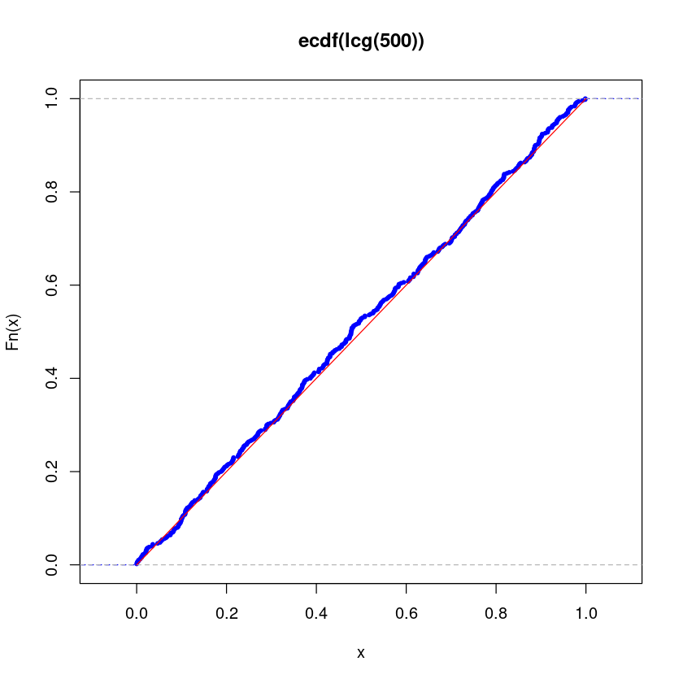

```r
plot(ecdf(lcg(500)), lty = "dashed", col = "blue", cex=0.5) # Função de distribuição acumulada empírica
curve(punif(x),0, 1,add=TRUE, col="red")
```

1. 320

2. 144

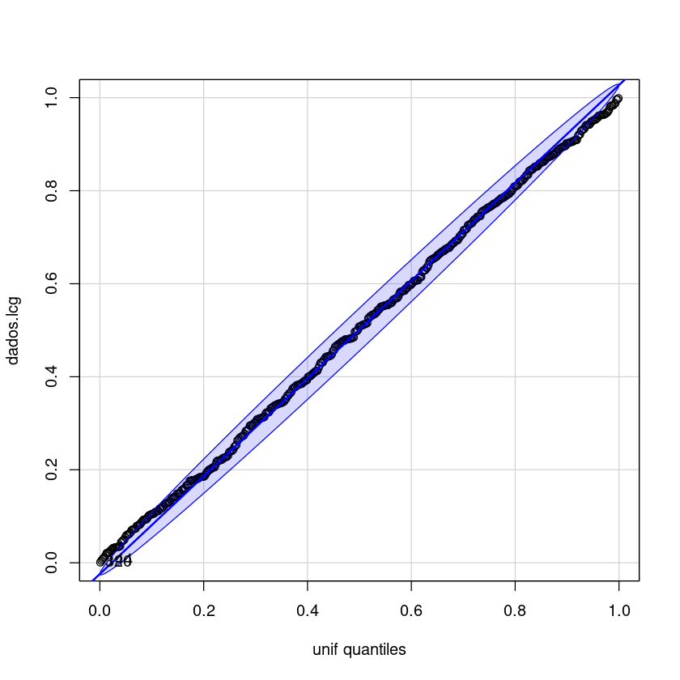

```r
# Gráfico de quantis
car::qqPlot(dados.lcg,dist="unif")
```

```r
# Teste de Kolmogorov-Smirnov
ks.test(dados.lcg, "punif")
```

```
	One-sample Kolmogorov-Smirnov test

data:  dados.lcg
D = 0.019896, p-value = 0.9889
alternative hypothesis: two-sided
```

```r
# Teste da frequência (Frequency test): Para verificar uniformidade
randtoolbox::freq.test(dados.lcg, 1:4)
```

```
			 Frequency test

chisq stat = 1.4, df = 3, p-value = 0.71

		 (sample size : 500)

	observed number	 130 118 119 133
	expected number	 125
```

```r
# Teste 'lacuna' (Gap test): Para verificar independência
randtoolbox::gap.test(dados.lcg)
```

```
			 Gap test

chisq stat = 37, df = 9, p-value = 2.8e-05

		 (sample size : 500)

length	observed freq		theoretical freq
1 			 56 			 62
2 			 25 			 31
3 			 13 			 16
4 			 7 			 7.8
5 			 6 			 3.9
6 			 3 			 2
7 			 0 			 0.98
8 			 0 			 0.49
9 			 3 			 0.24
10 			 0 			 0.12
```

```r
# Teste do Poker (Poker test): Para verificar independência
randtoolbox::poker.test(dados.lcg)
```

```
			 Poker test

chisq stat = 1.5, df = 4, p-value = 0.83

		 (sample size : 500)

	observed number	 0 8 51 39 2
	expected number	 0.16 9.6 48 38 3.8
```

```r
# Teste da ordem (Order test): Para verificar independência
randtoolbox::order.test(dados.lcg, d=5)
```

```
			 Order test

chisq stat = 118, df = 119, p-value = 0.5

		 (sample size : 500)

	observed number	 2 3 1 1 0 0 1 0 1 0 0 1 0 2 3 0 0 1 0 2 0 2 2 2 0 0 0 2 0 2 0 3 0 0 1 0 0 1 0 1 1 4 0 0 1 1 4 1 2 2 1 2 2 1 0 1 1 0 1 1 1 2 1 1 1 0 0 1 1 0 1 2 0 0 0 1 1 0 0 1 1 0 0 1 0 1 2 0 1 0 0 0 0 1 1 0 1 1 0 0 1 2 2 1 1 0 0 0 0 1 0 1 0 1 3 1 0 0 1 1
	expected number	 0.83
```

```r
# Teste de sequências (Runs test): Para verificar aleatoriedade
randtests::runs.test(dados.lcg)
```

```
	Runs Test

data:  dados.lcg
statistic = -2, runs = 225, n1 = 250, n2 = 250, n = 500, p-value = 0.02
alternative hypothesis: nonrandomness
```

```r
# Teste Turning points: Para verificar aleatoriedade
turning.point.test(dados.lcg)
```

```
	Turning Point Test

data:  dados.lcg
statistic = 0.4, n = 500, p-value = 0.7
alternative hypothesis: non randomness
```

```r
# Teste de diferenças de sinal (Difference sign test): Para verificar aleatoriedade
difference.sign.test(dados.lcg)
```

```
	Difference Sign Test

data:  dados.lcg
statistic = -0.08, n = 500, p-value = 0.9
alternative hypothesis: nonrandomness
```

```r
# Teste de Cox e Stuart
cox.stuart.test(dados.lcg)
```

```
	Cox Stuart test

data:  dados.lcg
statistic = 126, n = 250, p-value = 0.9
alternative hypothesis: non randomness
```

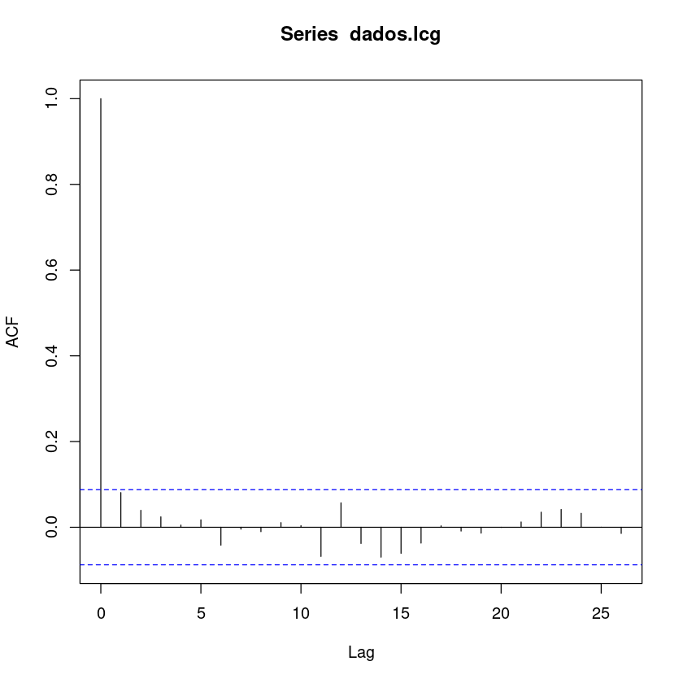

```r
# Função de autocorrelação
acf(dados.lcg)
```

# Calculando áreas

### Aproximando o valor de pi

[figure not shown]

### Aproximando o valor de pi

[figure not shown]

### Aproximando o valor de pi

```r
# Aproximando o valor de pi

options(digits=10)  # Define o número de casas decimais

pi.approx<-function(n=100, plot=TRUE){
    x<-lcg(n)
    y<-lcg(n)
    d<-(x^2+y^2<1)
    pi.approx<-4*(sum(d)/n)
    if(plot){
        obj = list(n=n, pi=pi.approx)
        plot(x,y,col=d+2,pch=20, main=bquote(paste("n" == .(obj$n),", ",pi==.(obj$pi))),cex.main=1.5)
        curve(sqrt(1-x^2), 0, 1,add=TRUE, col="blue")
    }
}
```

### Aproximando o valor de pi

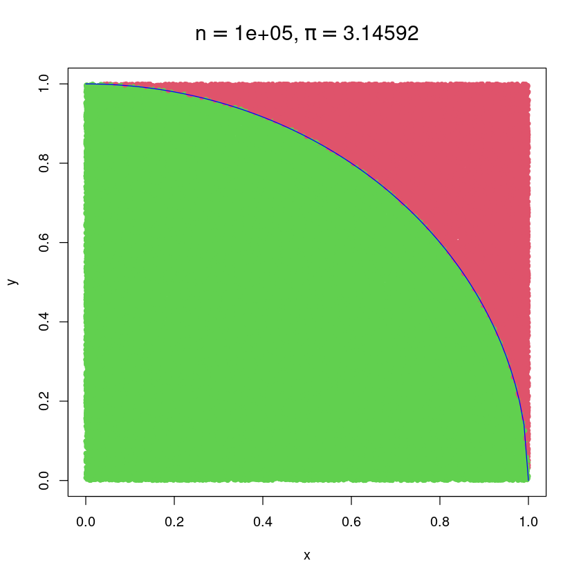

```r
pi.approx(n=100000,plot=T)
```

[figure not shown]